# Lubridate Package

Miraj Patel

2025-04-20

In this vignette, we will use lubridate package from the Tidyverse to parse and manipulate data that uses date and time. The data we will use is flights dataset in nycflights13 package. We will calculate departure delays and visualize the results.

First, lets install and load the necessary libraries.

Let’s load the flight dataset and get a glimpse of the dataset.

```
## Rows: 336,776
## Columns: 19
## $ year           <int> 2013, 2013, 2013, 2013, 2013, 2013, 2013, 2013, 2013, 2…
## $ month          <int> 1, 1, 1, 1, 1, 1, 1, 1, 1, 1, 1, 1, 1, 1, 1, 1, 1, 1, 1…
## $ day            <int> 1, 1, 1, 1, 1, 1, 1, 1, 1, 1, 1, 1, 1, 1, 1, 1, 1, 1, 1…
## $ dep_time       <int> 517, 533, 542, 544, 554, 554, 555, 557, 557, 558, 558, …
## $ sched_dep_time <int> 515, 529, 540, 545, 600, 558, 600, 600, 600, 600, 600, …
## $ dep_delay      <dbl> 2, 4, 2, -1, -6, -4, -5, -3, -3, -2, -2, -2, -2, -2, -1…
## $ arr_time       <int> 830, 850, 923, 1004, 812, 740, 913, 709, 838, 753, 849,…
## $ sched_arr_time <int> 819, 830, 850, 1022, 837, 728, 854, 723, 846, 745, 851,…
## $ arr_delay      <dbl> 11, 20, 33, -18, -25, 12, 19, -14, -8, 8, -2, -3, 7, -1…
## $ carrier        <chr> "UA", "UA", "AA", "B6", "DL", "UA", "B6", "EV", "B6", "…
## $ flight         <int> 1545, 1714, 1141, 725, 461, 1696, 507, 5708, 79, 301, 4…
## $ tailnum        <chr> "N14228", "N24211", "N619AA", "N804JB", "N668DN", "N394…
## $ origin         <chr> "EWR", "LGA", "JFK", "JFK", "LGA", "EWR", "EWR", "LGA",…
## $ dest           <chr> "IAH", "IAH", "MIA", "BQN", "ATL", "ORD", "FLL", "IAD",…
## $ air_time       <dbl> 227, 227, 160, 183, 116, 150, 158, 53, 140, 138, 149, 1…
## $ distance       <dbl> 1400, 1416, 1089, 1576, 762, 719, 1065, 229, 944, 733, …
## $ hour           <dbl> 5, 5, 5, 5, 6, 5, 6, 6, 6, 6, 6, 6, 6, 6, 6, 5, 6, 6, 6…
## $ minute         <dbl> 15, 29, 40, 45, 0, 58, 0, 0, 0, 0, 0, 0, 0, 0, 0, 59, 0…
## $ time_hour      <dttm> 2013-01-01 05:00:00, 2013-01-01 05:00:00, 2013-01-01 0…
```

After the glimpse of the dataset, we will use functions in the lubridate package to convert date and time columns into proper datetime objects.

With this, we have 3 new columns in the dataset. The date is combined into one column and the times are combined into one column for easier readability and analysis.

Next, we will convert the departure delay values into a numeric format for easier analysis. Then we will summarize the average departure delay for each day of the week and create a visualization to present the findings.

We will use wday function from the lubridate package to figure out what day of the week the date of departure fell on.

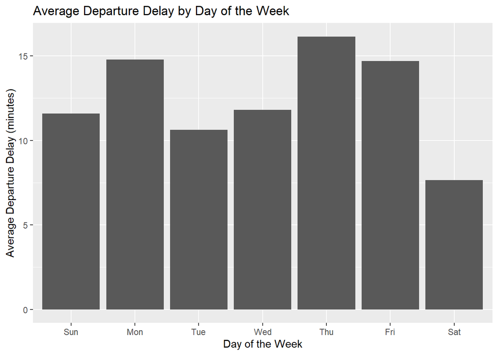

In this vignette, we utilized the lubridate package to parse and manipulate date and time data in one of the nycflights13 dataset. We calculated departure delays and visualized the average delays by each day of the week. Using lubridate package made it easier to perfrom these analyses.

## Extending example with map2_dbl from purrr

Let’s operate on flights to see which carrier has the lowest median flight. This could tell us which carrier typically does not have flights outside of a small range.

We will use `map2_dbl` from `purrr` for the example. There are many other ways to combine hours and minutes together into a consistent form, but this allows us to see the power of mapping functions in `purrr`. You can create short custom in-line functions using ~ in one of the map functions. Hour * 60 + minute is a simple calculation and is suited for this purpose. Afterwards, group the separate flights for each carrier together and find the median minutes for them.

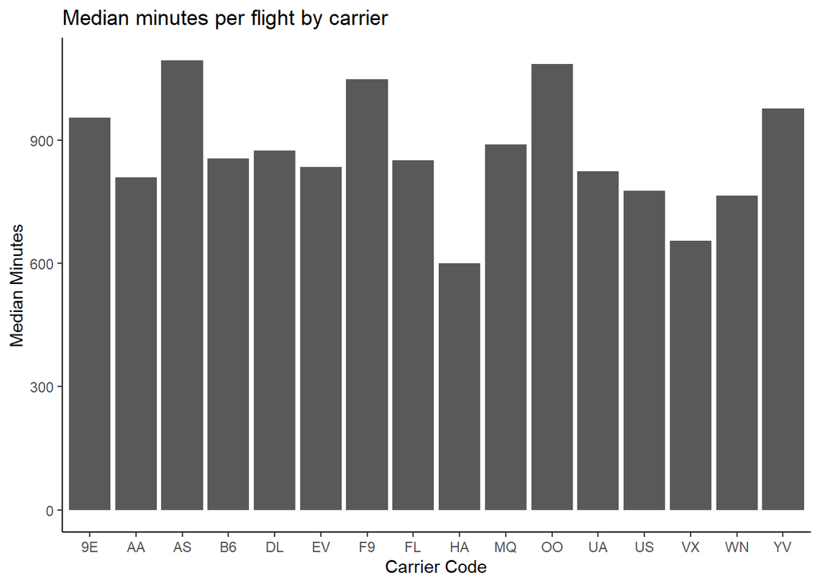

## Time Zones Handling

```
## [1] "1970-01-01 00:17:00 EST" "1970-01-01 00:33:00 EST"
## [3] "1970-01-01 00:42:00 EST" "1970-01-01 00:44:00 EST"
## [5] "1970-01-01 00:54:00 EST" "1970-01-01 00:54:00 EST"
```

## Adding a Date Range Filter

Displaying flight of a selected date range. Then will visulize post summary.

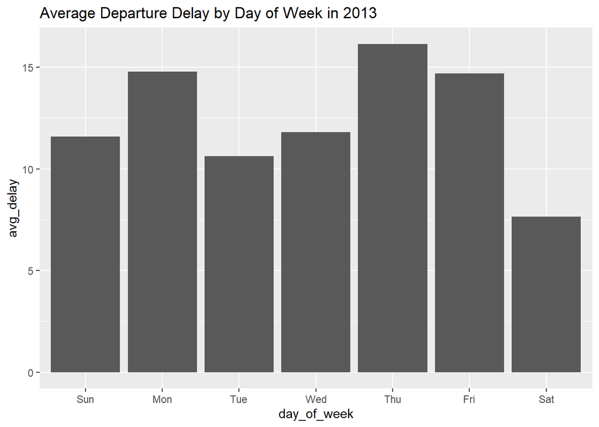

## Create Custom Date Function

With lubridate custom date-time can be created, and future combinations for advance manipulatioin.

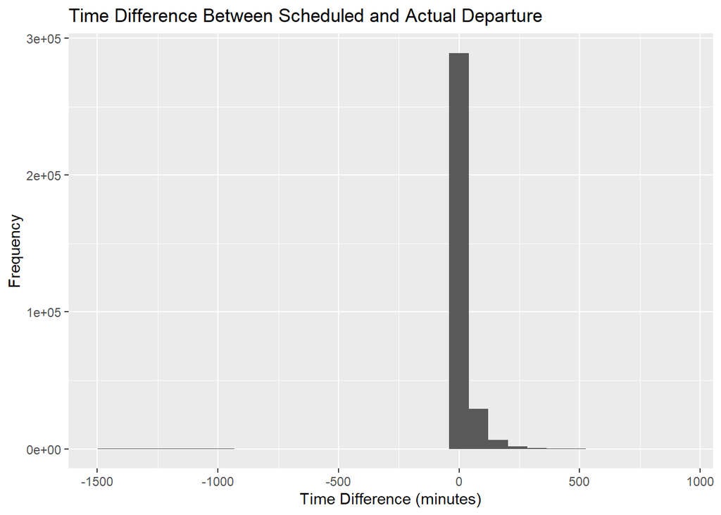

## Conclusion The following extension will enhanced the original vignette to a broader analysis, introducing functionality from lubridate, will help demonstrate more effectively to visualize time pattern.